# A7: Project Assignment

Prabhudatta Mohapatra

December 05, 2023

# 1 Task 0: Importing Data and Summary

```r
# setting up working directory
wd<- getwd()
setwd(wd)

# loading required libraries
library(knitr)
library(rmarkdown)
library(matrixStats)
library(tidyverse)
library(dplyr)
library(psych)
library(rJava)
library(RWeka)
library(rminer)
library(scatterplot3d)
library(rpart)
library(rpart.plot)
library(caret)
library(C50)
library(e1071)
library(kernlab)
library(dlookr)

# Importing data with stringsAsFactors = False
data <- read.csv("census.csv", stringsAsFactors = FALSE)
```

# 2 Task I: EDA

```r
# structure of the input file
str(data)
```

```
## 'data.frame':    32561 obs. of  15 variables:
##  $ age           : int  39 50 38 53 28 37 49 52 31 42 ...
##  $ workclass     : chr  " State-gov" " Self-emp-not-inc" " Private" " Private" ...
##  $ fnlwgt        : int  77516 83311 215646 234721 338409 284582 160187 209642 45781 159449 ...
##  $ education     : chr  " Bachelors" " Bachelors" " HS-grad" " 11th" ...
##  $ education.num : int  13 13 9 7 13 14 5 9 14 13 ...
##  $ marital.status: chr  " Never-married" " Married-civ-spouse" " Divorced" " Married-civ-spouse" ...
##  $ occupation    : chr  " Adm-clerical" " Exec-managerial" " Handlers-cleaners" " Handlers-cleaners" ...
##  $ relationship  : chr  " Not-in-family" " Husband" " Not-in-family" " Husband" ...
##  $ race          : chr  " White" " White" " White" " Black" ...
##  $ sex           : chr  " Male" " Male" " Male" " Male" ...
##  $ capital.gain  : int  2174 0 0 0 0 0 0 0 14084 5178 ...
##  $ capital.loss  : int  0 0 0 0 0 0 0 0 0 0 ...
##  $ hours.per.week: int  40 13 40 40 40 40 16 45 50 40 ...
##  $ native.country: chr  " United-States" " United-States" " United-States" " United-States" ...
##  $ y             : chr  " <=50K" " <=50K" " <=50K" " <=50K" ...
```

```r
# checking first 10 observations
data %>% head(10)
```

```
##    age         workclass fnlwgt  education education.num         marital.status
## 1   39         State-gov  77516  Bachelors            13          Never-married
## 2   50  Self-emp-not-inc  83311  Bachelors            13     Married-civ-spouse
## 3   38           Private 215646    HS-grad             9               Divorced
## 4   53           Private 234721       11th             7     Married-civ-spouse
## 5   28           Private 338409  Bachelors            13     Married-civ-spouse
## 6   37           Private 284582    Masters            14     Married-civ-spouse
## 7   49           Private 160187        9th             5  Married-spouse-absent
## 8   52  Self-emp-not-inc 209642    HS-grad             9     Married-civ-spouse
## 9   31           Private  45781    Masters            14          Never-married
## 10  42           Private 159449  Bachelors            13     Married-civ-spouse
##            occupation   relationship   race     sex capital.gain capital.loss
## 1        Adm-clerical  Not-in-family  White    Male         2174            0
## 2     Exec-managerial        Husband  White    Male            0            0
## 3   Handlers-cleaners  Not-in-family  White    Male            0            0
```

[output cut: 18 more lines]

```r
# checking last 10 observations
data %>% tail(10)
```

```
##       age     workclass fnlwgt     education education.num      marital.status
## 32552  32       Private  34066          10th             6  Married-civ-spouse
## 32553  43       Private  84661     Assoc-voc            11  Married-civ-spouse
## 32554  32       Private 116138       Masters            14       Never-married
## 32555  53       Private 321865       Masters            14  Married-civ-spouse
## 32556  22       Private 310152  Some-college            10       Never-married
## 32557  27       Private 257302    Assoc-acdm            12  Married-civ-spouse
## 32558  40       Private 154374       HS-grad             9  Married-civ-spouse
## 32559  58       Private 151910       HS-grad             9             Widowed
## 32560  22       Private 201490       HS-grad             9       Never-married
## 32561  52  Self-emp-inc 287927       HS-grad             9  Married-civ-spouse
##               occupation   relationship                race     sex
## 32552  Handlers-cleaners        Husband  Amer-Indian-Eskimo    Male
## 32553              Sales        Husband               White    Male
## 32554       Tech-support  Not-in-family  Asian-Pac-Islander    Male
```

[output cut: 18 more lines]

```r
#summary
summary(data)
```

```
##       age         workclass             fnlwgt         education
##  Min.   :17.00   Length:32561       Min.   :  12285   Length:32561
##  1st Qu.:28.00   Class :character   1st Qu.: 117827   Class :character
##  Median :37.00   Mode  :character   Median : 178356   Mode  :character
##  Mean   :38.58                      Mean   : 189778
##  3rd Qu.:48.00                      3rd Qu.: 237051
##  Max.   :90.00                      Max.   :1484705
##  education.num   marital.status      occupation        relationship
##  Min.   : 1.00   Length:32561       Length:32561       Length:32561
##  1st Qu.: 9.00   Class :character   Class :character   Class :character
##  Median :10.00   Mode  :character   Mode  :character   Mode  :character
##  Mean   :10.08
##  3rd Qu.:12.00
##  Max.   :16.00
##      race               sex             capital.gain    capital.loss
##  Length:32561       Length:32561       Min.   :    0   Min.   :   0.0
##  Class :character   Class :character   1st Qu.:    0   1st Qu.:   0.0
##  Mode  :character   Mode  :character   Median :    0   Median :   0.0
##                                        Mean   : 1078   Mean   :  87.3
##                                        3rd Qu.:    0   3rd Qu.:   0.0
##                                        Max.   :99999   Max.   :4356.0
##  hours.per.week  native.country          y
##  Min.   : 1.00   Length:32561       Length:32561
##  1st Qu.:40.00   Class :character   Class :character
##  Median :40.00   Mode  :character   Mode  :character
##  Mean   :40.44
##  3rd Qu.:45.00
##  Max.   :99.00
```

```r
# Categorical Variables
table(data$workclass)
```

```
##
##                 ?       Federal-gov         Local-gov      Never-worked
##              1836               960              2093                 7
##           Private      Self-emp-inc  Self-emp-not-inc         State-gov
##             22696              1116              2541              1298
##       Without-pay
##                14
```

```r
table(data$education)
```

```
##
##          10th          11th          12th       1st-4th       5th-6th
##           933          1175           433           168           333
##       7th-8th           9th    Assoc-acdm     Assoc-voc     Bachelors
##           646           514          1067          1382          5355
##     Doctorate       HS-grad       Masters     Preschool   Prof-school
##           413         10501          1723            51           576
##  Some-college
##          7291
```

```r
table(data$education.num)
```

```
##
##     1     2     3     4     5     6     7     8     9    10    11    12    13
##    51   168   333   646   514   933  1175   433 10501  7291  1382  1067  5355
##    14    15    16
##  1723   576   413
```

```r
table(data$occupation)
```

```
##
##                  ?       Adm-clerical       Armed-Forces       Craft-repair
##               1843               3770                  9               4099
##    Exec-managerial    Farming-fishing  Handlers-cleaners  Machine-op-inspct
##               4066                994               1370               2002
##      Other-service    Priv-house-serv     Prof-specialty    Protective-serv
##               3295                149               4140                649
##              Sales       Tech-support   Transport-moving
##               3650                928               1597
```

```r
table(data$relationship)
```

```
##
##         Husband   Not-in-family  Other-relative       Own-child       Unmarried
##           13193            8305             981            5068            3446
##            Wife
##            1568
```

```r
table(data$race)
```

```
##
##  Amer-Indian-Eskimo  Asian-Pac-Islander               Black               Other
##                 311                1039                3124                 271
##               White
##               27816
```

```r
table(data$sex)
```

```
##
##  Female    Male
##   10771   21790
```

```r
table(data$native.country)
```

```
##
##                           ?                    Cambodia
##                         583                          19
##                      Canada                       China
##                         121                          75
##                    Columbia                        Cuba
##                          59                          95
##          Dominican-Republic                     Ecuador
##                          70                          28
##                 El-Salvador                     England
##                         106                          90
##                      France                     Germany
##                          29                         137
##                      Greece                   Guatemala
##                          29                          64
##                       Haiti          Holand-Netherlands
##                          44                           1
##                    Honduras                        Hong
##                          13                          20
##                     Hungary                       India
##                          13                         100
##                        Iran                     Ireland
##                          43                          24
##                       Italy                     Jamaica
##                          73                          81
##                       Japan                        Laos
##                          62                          18
##                      Mexico                   Nicaragua
##                         643                          34
##  Outlying-US(Guam-USVI-etc)                        Peru
##                          14                          31
##                 Philippines                      Poland
##                         198                          60
##                    Portugal                 Puerto-Rico
##                          37                         114
##                    Scotland                       South
##                          12                          80
##                      Taiwan                    Thailand
##                          51                          18
##             Trinadad&Tobago               United-States
##                          19                       29170
##                     Vietnam                  Yugoslavia
##                          67                          16
```

```r
table(data$y)
```

```
##
##  <=50K   >50K
##  24720   7841
```

```r
# checking missing values
data %>% summarize(across(everything(), ~ sum(is.na(.))))
```

```
##   age workclass fnlwgt education education.num marital.status occupation
## 1   0         0      0         0             0              0          0
##   relationship race sex capital.gain capital.loss hours.per.week native.country
## 1            0    0   0            0            0              0              0
##   y
## 1 0
```

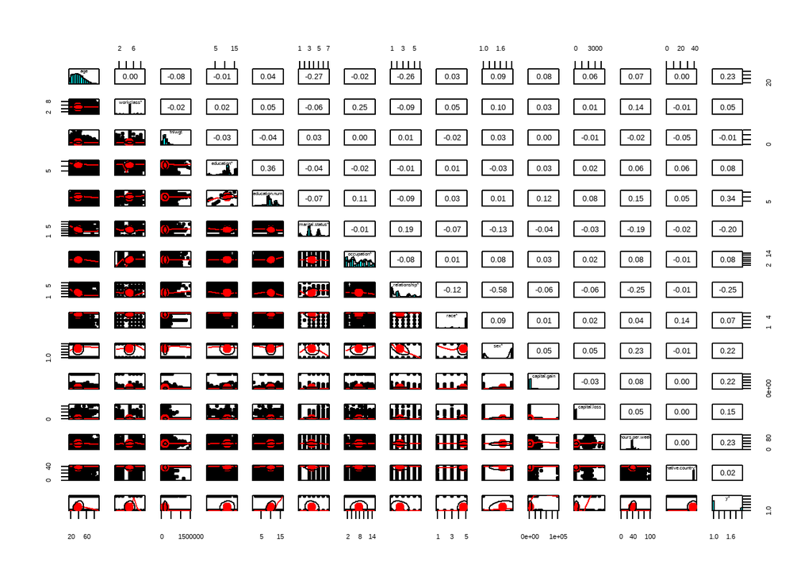

```r
#Checking correlation whole data
pairs.panels(data)
```

```r
#checking categorical variables
prop.table(table(data$y, data$workclass))
```

```
##
##                     ?  Federal-gov    Local-gov  Never-worked      Private
##    <=50K 0.0505205614 0.0180891250 0.0453303031  0.0002149811 0.5446085808
##    >50K  0.0058659132 0.0113939990 0.0189490495  0.0000000000 0.1524216087
##
##           Self-emp-inc  Self-emp-not-inc    State-gov  Without-pay
##    <=50K  0.0151715242      0.0558029545 0.0290224502 0.0004299622
##    >50K   0.0191026074      0.0222351893 0.0108411904 0.0000000000
```

```r
prop.table(table(data$y, data$education))
```

```
##
##                  10th         11th         12th      1st-4th      5th-6th
##    <=50K 0.0267497927 0.0342434200 0.0122846350 0.0049752772 0.0097355732
##    >50K  0.0019041184 0.0018426952 0.0010134824 0.0001842695 0.0004913854
##
##               7th-8th          9th   Assoc-acdm    Assoc-voc    Bachelors
##    <=50K 0.0186112220 0.0149565431 0.0246306932 0.0313565308 0.0962501152
##    >50K  0.0012284635 0.0008292129 0.0081385707 0.0110868831 0.0682104358
##
##             Doctorate      HS-grad      Masters    Preschool  Prof-school
##    <=50K 0.0032861399 0.2710604711 0.0234636528 0.0015662910 0.0046988729
##    >50K  0.0093977458 0.0514419090 0.0294524124 0.0000000000 0.0129910015
##
##           Some-college
##    <=50K  0.1813212125
##    >50K   0.0425969718
```

```r
prop.table(table(data$y, data$marital.status))
```

```
##
##              Divorced  Married-AF-spouse  Married-civ-spouse
##    <=50K 0.1222321182       0.0003992506        0.2544147907
##    >50K  0.0142194650       0.0003071159        0.2055219434
##
##           Married-spouse-absent  Never-married    Separated      Widowed
##    <=50K           0.0117932496   0.3130124996 0.0294524124 0.0278861214
##    >50K            0.0010441940   0.0150793895 0.0020269648 0.0026104849
```

```r
prop.table(table(data$y, data$race))
```

```
##
##           Amer-Indian-Eskimo  Asian-Pac-Islander        Black        Other
##    <=50K        0.0084456866        0.0234329412 0.0840576149 0.0075550505
##    >50K         0.0011056171        0.0084763981 0.0118853844 0.0007677897
##
##                 White
##    <=50K 0.6356991493
##    >50K  0.2185743681
```

```r
prop.table(table(data$y, data$sex))
```

```
##
##              Female       Male
##    <=50K 0.29458555 0.46460490
##    >50K  0.03620896 0.20460060
```

```r
prop.table(table(data$y))
```

```
##
##     <=50K      >50K
## 0.7591904 0.2408096
```

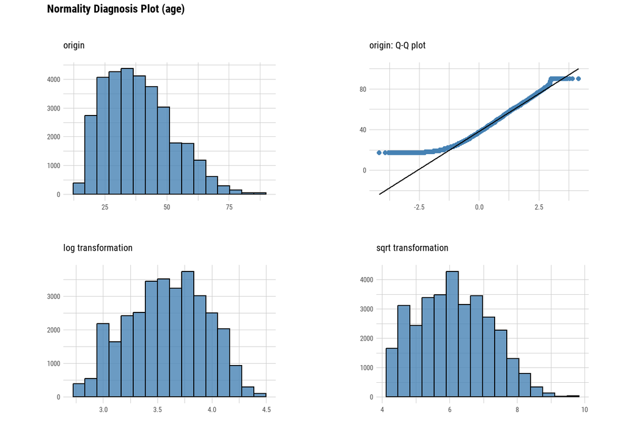

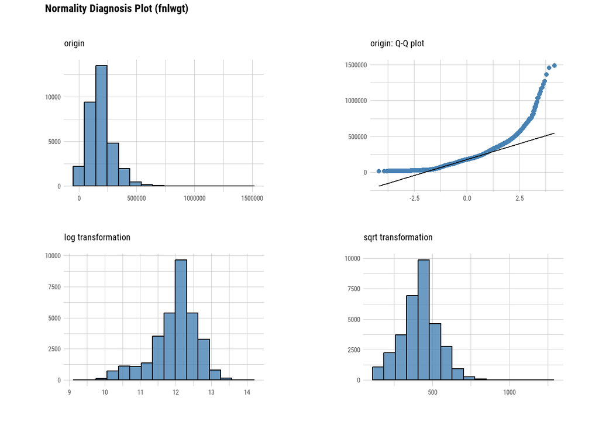

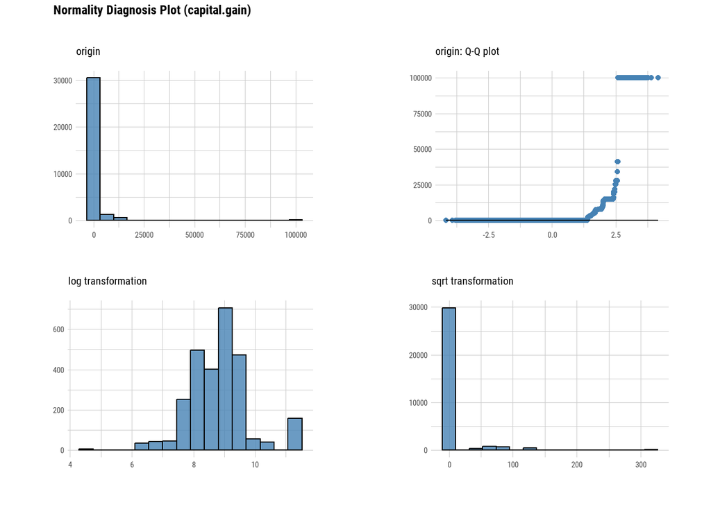

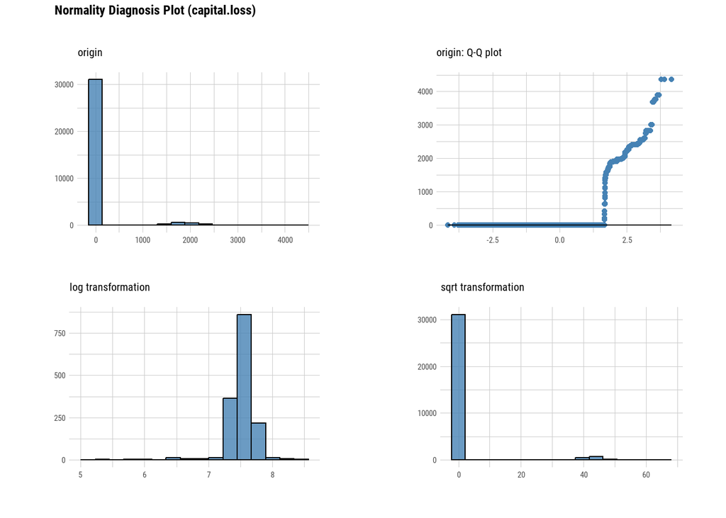

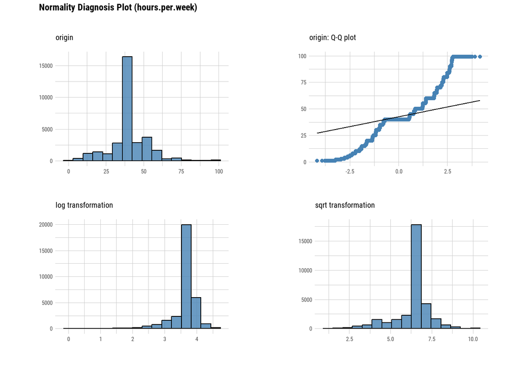

```r
# Checking data distribution and normality
data %>% select(age, fnlwgt, capital.gain, capital.loss, hours.per.week) %>% plot_normality()
```

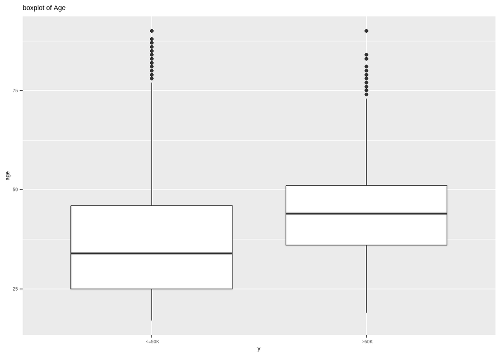

```r
data %>%  ggplot(aes(x = y, y=age)) + geom_boxplot() + ggtitle('boxplot of Age')
```

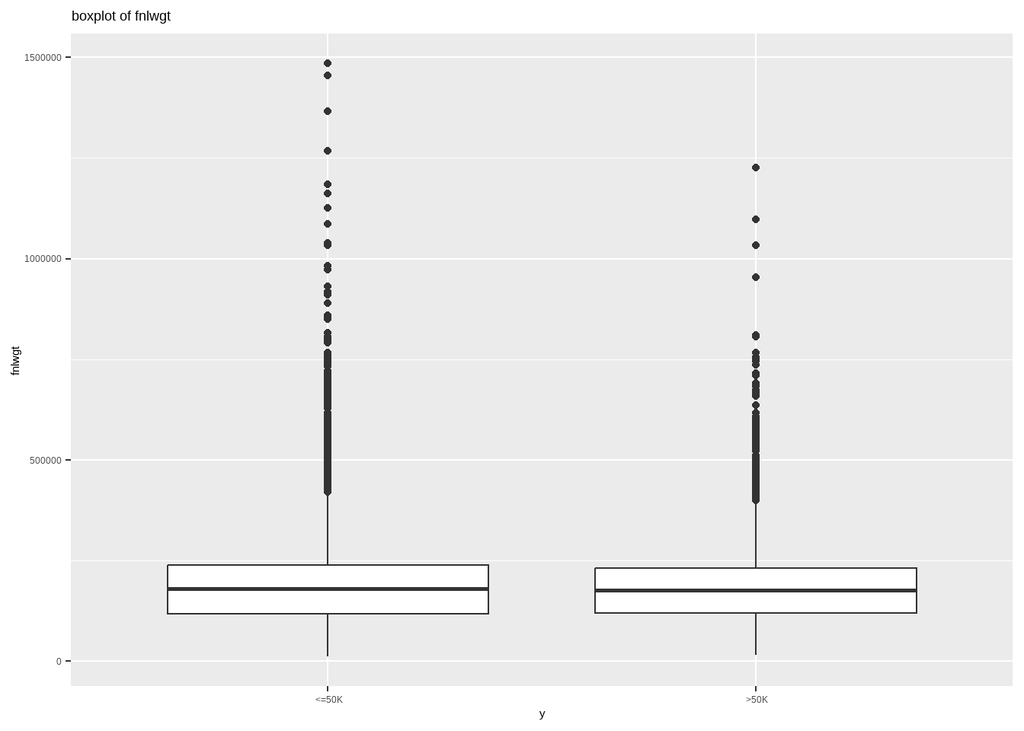

```r
data %>%  ggplot(aes(x = y, y=fnlwgt)) + geom_boxplot() + ggtitle('boxplot of fnlwgt')
```

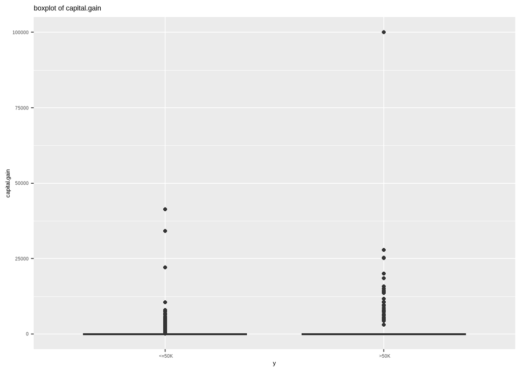

```r
data %>%  ggplot(aes(x = y, y=capital.gain)) + geom_boxplot() + ggtitle('boxplot of capital.gain')
```

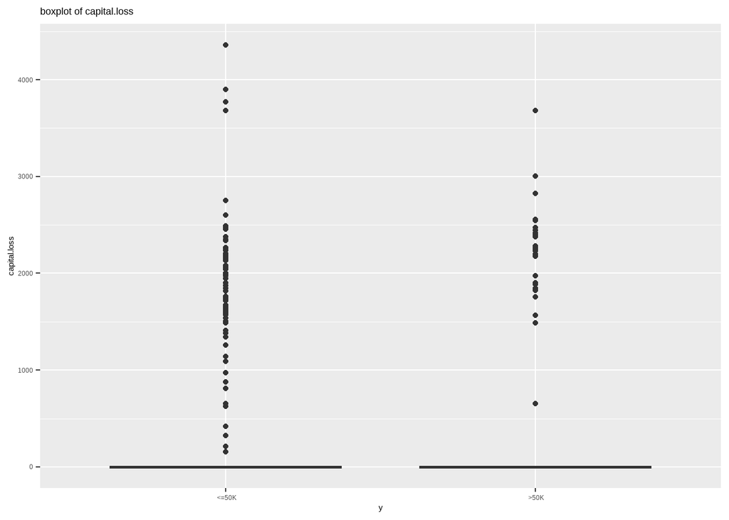

```r
data %>%  ggplot(aes(x = y, y=capital.loss)) + geom_boxplot() + ggtitle('boxplot of capital.loss')
```

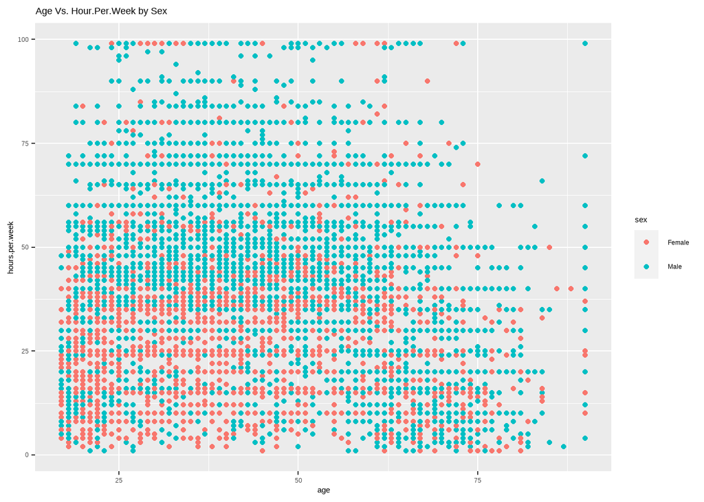

```r
# plot for age and hours.per.week stratified by sex
data %>% ggplot() + geom_point(aes(x = age,y=hours.per.week, color = sex)) + ggtitle("Age Vs. Hour.Per.Week by Sex")
```

## Data Features

- There are 32561 observations (rows) and 15 variables (columns) in the data set.
- Variables are in different data type: int (age, fnlwgt, eductaion.num, capital.gain, etc.) and chr (workclass, education,education, marital.status, occupation, etc.)
- It is observed that each character variable has leading blank space for data points.
- There are multiple ‘?’ special character present through out the column workclass, occupation, and native country.
- Target variable is if someone has salary more than 50K or less than 50K. So, it is a categorical variable and binary classification models will be created. There are 24720 observations having less than 50K salary and 7841 observations having more than 50k salary. So, 75.92% of observations have salary less than 50K and 24.08% of observations have salary more than 50K.
- There is no missing value across the data set
- List of the supervised models **appropriate** to use for the task in this project (classification):
  1. Decision Tree (C5.0)
  2. Recursive partitioning for classification (rpart)
  3. Naïve Bayes (naiveBayes)
  4. Support Vector Machines (ksvm)
  5. Multi-Layer Perceptrons (MLP)
- List of the supervised models **not** appropriate to use for the task in this project (classification):
  1. Liner Regression (lm)
  2. M5 (regression) model trees (M5P)
- Education and Education.num represents same thing. Only of these variables can be used in classification model.
- Very low percentage of women are getting salary above >=50K.
- From the boxplot of Age, median age of people getting more than 50K salary is higher than age of the people getting less than 50K salary. Also, range of age for people getting less than 50K is higher than range of age of people getting more than 50K salary.
- From the boxplot of fnlwgt, median fnlwgt of people getting more than 50K salary is alomost same as fnlwgt of the people getting less than 50K salary.
- From the boxplot of capital.gain and capital.loss it can be observed that most of the values are zero. There is an extreme outlier for the salary more than 50K in capital gain.
- From the scatter plot it can be observed that more males are working more than 40 hours per week as compared to the females.
- From the pair.panels plot no significant correlation between numeric variables is observed.
- From the normality plot it can be observed that age is right skewed and a log transform will approx normality. Similarly, fnlwgt is highly right skewed and log transformation will approx normality. Hours.per.week appears to be symmetric though do not have normal distribution. Capital.gain and Capital.loss has majority of data points as zero (0) and log transformation will introduce ‘-inf’ and adding a constant of ‘1’ before log transformation does not make the data distribution any better.

# 3 Task II: Data Preparation

```r
# removing leading blank space from column data point
data$workclass <- trimws(data$workclass, which = c("left"))
data$education <- (trimws(data$education, which = c("left")))
data$marital.status<- (trimws(data$marital.status, which = c("left")))
data$occupation <- (trimws(data$occupation, which = c("left")))
data$relationship <- (trimws(data$relationship, which = c("left")))
data$race <- (trimws(data$race, which = c("left")))
data$sex <- (trimws(data$sex, which = c("left")))
data$native.country <- (trimws(data$native.country, which = c("left")))
data$y <- (trimws(data$y, which = c("left")))


# setting '?' as other category as it is not given if the values are missing or not
data$workclass[as.character(data$workclass) == "?"] <- "other"
data$occupation[as.character(data$occupation) == "?"] <- "other"
data$native.country[as.character(data$native.country) == "?"] <- "other"

# transform target variable
data$y <- ifelse(data$y == "<=50K",0,1)

# removing eductaion.num
data<- data %>% select(-education.num)

# transform all character variables to factors except 'Name'
data <- data %>% mutate(across(c(workclass, education, marital.status,occupation,relationship, race, sex, native.country, y),factor))

# based on the data distribution log transformation
data$age<-log(data$age) # right skewed
data$fnlwgt <- log(data$fnlwgt) # right skewed

# Summary after data transformation
summary(data)
```

```
##       age                   workclass         fnlwgt              education
##  Min.   :2.833   Private         :22696   Min.   : 9.416   HS-grad     :10501
##  1st Qu.:3.332   Self-emp-not-inc: 2541   1st Qu.:11.677   Some-college: 7291
##  Median :3.611   Local-gov       : 2093   Median :12.092   Bachelors   : 5355
##  Mean   :3.589   other           : 1836   Mean   :11.984   Masters     : 1723
##  3rd Qu.:3.871   State-gov       : 1298   3rd Qu.:12.376   Assoc-voc   : 1382
##  Max.   :4.500   Self-emp-inc    : 1116   Max.   :14.211   11th        : 1175
##                  (Other)         :  981                    (Other)     : 5134
##                marital.status            occupation           relationship
##  Divorced             : 4443   Prof-specialty :4140   Husband       :13193
##  Married-AF-spouse    :   23   Craft-repair   :4099   Not-in-family : 8305
##  Married-civ-spouse   :14976   Exec-managerial:4066   Other-relative:  981
##  Married-spouse-absent:  418   Adm-clerical   :3770   Own-child     : 5068
##  Never-married        :10683   Sales          :3650   Unmarried     : 3446
##  Separated            : 1025   Other-service  :3295   Wife          : 1568
##  Widowed              :  993   (Other)        :9541
##                  race           sex         capital.gain    capital.loss
##  Amer-Indian-Eskimo:  311   Female:10771   Min.   :    0   Min.   :   0.0
##  Asian-Pac-Islander: 1039   Male  :21790   1st Qu.:    0   1st Qu.:   0.0
##  Black             : 3124                  Median :    0   Median :   0.0
##  Other             :  271                  Mean   : 1078   Mean   :  87.3
##  White             :27816                  3rd Qu.:    0   3rd Qu.:   0.0
##                                            Max.   :99999   Max.   :4356.0
##
##  hours.per.week        native.country  y
##  Min.   : 1.00   United-States:29170   0:24720
##  1st Qu.:40.00   Mexico       :  643   1: 7841
##  Median :40.00   other        :  583
##  Mean   :40.44   Philippines  :  198
##  3rd Qu.:45.00   Germany      :  137
##  Max.   :99.00   Canada       :  121
##                  (Other)      : 1709
```

## 3.1 Data Preparation

- Leading blank space from the character variables have been removed.
- All ‘?’ are assigned to the other category in workclass, occupation, and native.country variables as there is no information about the missing data is provided
- Target variable is transformed to binary as <=50K is assigned 0 and >50K is assigned as 1.
- As education and education.num represents same thing education.num is removed and education is kept as having labels would be easier to interpret the model results.
- All character variables are converted to factors (workclass, education, marital.status,occupation,relationship, race, sex, native.country, y).
- As observed from the normality plot age is right skewed so it is log transformed to approx normality or being symmetric
- As observed from the normality plot fnlwgt is right skewed so it is log transformed to approx normality or being symmetric.

```r
#Setting a random seed
set.seed(100)
# Row Index
inTrain <- createDataPartition(data$y, p=0.7, list=FALSE)
# Data Partition
train_data <- data[inTrain,]
test_data <- data[-inTrain,]

train_target <- data[inTrain,14]
test_target <- data[-inTrain,14]
train_input <- data[inTrain,-14]
test_input <- data[-inTrain,-14]


# 1.C

# Distribution of y in the whole data set
prop.table(table(data$y)) * 100
```

```
##
##        0        1
## 75.91904 24.08096
```

```r
# Distribution of y in the train data set
prop.table(table(train_target)) * 100
```

```
## train_target
##        0        1
## 75.91805 24.08195
```

```r
# Count & Distribution of y in the test data set
prop.table(table(test_target)) * 100
```

```
## test_target
##        0        1
## 75.92138 24.07862
```

## 3.2 Data Partition

- Data has been partitioned into train and test data set based on a 70:30 split. It can be observed that data is partitioned nicely and target variable(y) proportion is same across the three data sets.y variable is distributed similarly, having approx. 75.92% (0 or <=50K salary) and approx. 24.08% (1 or >50k salary).

# 4 Task III: Model Building

```r
tree_cf_model <- C5.0(train_target ~ .,train_input,control = C5.0Control(CF= 0.1,earlyStopping = FALSE, noGlobalPruning = FALSE))
tree_cf_model
```

```
##
## Call:
## C5.0.formula(formula = train_target ~ ., data = train_input, control
##  = C5.0Control(CF = 0.1, earlyStopping = FALSE, noGlobalPruning = FALSE))
##
## Classification Tree
## Number of samples: 22793
## Number of predictors: 13
##
## Tree size: 38
##
## Non-standard options: attempt to group attributes, confidence level: 0.1
```

```r
# Train data prediction
tree_cf_train_predictions <- predict(tree_cf_model,train_input)
# Test data prediction
tree_cf_test_predictions <- predict(tree_cf_model,test_input)

# Confusion matrix for train data prediction
mmetric(train_target, tree_cf_train_predictions, metric="CONF")$conf
```

```
##       pred
## target     0     1
##      0 16360   944
##      1  1955  3534
```

```r
# Confusion matrix for test data prediction
mmetric(test_target, tree_cf_test_predictions, metric="CONF")$conf
```

```
##       pred
## target    0    1
##      0 6978  438
##      1  863 1489
```

```r
#Evaluation metrics for train data prediction
mmetric(train_target, tree_cf_train_predictions, metric= c("ACC","TPR","PRECISION","F1"))
```

```
##        ACC       TPR1       TPR2 PRECISION1 PRECISION2        F11        F12
##   87.28118   94.54461   64.38331   89.32569   78.91916   91.86109   70.91402
```

```r
#Evaluation metrics for test data prediction
mmetric(test_target, tree_cf_test_predictions, metric= c("ACC","TPR","PRECISION","F1"))
```

```
##        ACC       TPR1       TPR2 PRECISION1 PRECISION2        F11        F12
##   86.68100   94.09385   63.30782   88.99375   77.27037   91.47277   69.59570
```

```r
# Feature Importance
C5imp(tree_cf_model)
```

```
##                Overall
## capital.gain    100.00
## relationship     95.06
## capital.loss     95.06
## education        39.01
## age              36.09
## hours.per.week   29.75
## occupation       26.41
## race             17.64
## workclass         6.93
## marital.status    0.51
## fnlwgt            0.00
## sex               0.00
## native.country    0.00
```

```r
cv_function0 <- function(df, target, nFolds, seedVal, classification, metrics_list)
{

  set.seed(seedVal)
  folds = createFolds(df[,target],nFolds)
  metrics_list <- c("ACC","PRECISION","TPR","F1")

 cv_results <- lapply(folds, function(x)
 {
   train <- df[-x,-target]
   test  <- df[x,-target]

   train_target <- df[-x,target]
   test_target <- df[x,target]

   classification_model <- classification(train,train_target)

   pred<- predict(classification_model,test)

   return(mmetric(test_target,pred,metrics_list))
 })

 cv_results_m <- as.matrix(as.data.frame(cv_results))

 cv_mean<- as.matrix(rowMeans(cv_results_m))

 colnames(cv_mean) <- "Mean"

 cv_sd <- as.matrix(rowSds(cv_results_m))

 colnames(cv_sd) <- "Sd"

 cv_all <- as.data.frame(cbind(cv_results_m, cv_mean, cv_sd))

 kable(cv_all,digits=2, align=rep('c', 10))
}
cv_c5.0<-cv_function0(metrics_list =  metrics_list,
            df = data,
            target = 14,
            nFolds = 10,
            seed = 100,
            classification =  C5.0)
cv_c5.0
```

|  | Fold01 | Fold02 | Fold03 | Fold04 | Fold05 | Fold06 | Fold07 | Fold08 | Fold09 | Fold10 | Mean | Sd |
| --- | --- | --- | --- | --- | --- | --- | --- | --- | --- | --- | --- | --- |
| ACC | 87.01 | 86.77 | 86.64 | 87.93 | 87.71 | 87.10 | 87.41 | 87.35 | 86.86 | 86.52 | 87.13 | 0.46 |
| PRECISION1 | 89.51 | 89.63 | 88.83 | 90.91 | 89.91 | 89.80 | 89.90 | 90.11 | 90.17 | 89.51 | 89.83 | 0.54 |
| PRECISION2 | 77.22 | 75.95 | 77.57 | 77.34 | 79.09 | 76.84 | 77.83 | 77.03 | 75.00 | 75.26 | 76.91 | 1.23 |
| TPR1 | 93.89 | 93.37 | 94.26 | 93.45 | 94.42 | 93.65 | 93.97 | 93.61 | 92.80 | 93.16 | 93.66 | 0.49 |
| TPR2 | 65.31 | 65.99 | 62.63 | 70.54 | 66.58 | 66.45 | 66.71 | 67.60 | 68.11 | 65.56 | 66.55 | 2.05 |
| F11 | 91.65 | 91.46 | 91.46 | 92.16 | 92.11 | 91.68 | 91.89 | 91.83 | 91.47 | 91.30 | 91.70 | 0.29 |
| F12 | 70.77 | 70.62 | 69.30 | 73.78 | 72.30 | 71.27 | 71.84 | 72.01 | 71.39 | 70.07 | 71.34 | 1.26 |

```r
tree_rpart_model <- rpart(train_target ~ .,train_input)
tree_rpart_model
```

```
## n= 22793
##
## node), split, n, loss, yval, (yprob)
##       * denotes terminal node
##
##  1) root 22793 5489 0 (0.759180450 0.240819550)
##    2) relationship=Not-in-family,Other-relative,Own-child,Unmarried 12518  817 0 (0.934733983 0.065266017)
##      4) capital.gain< 7073.5 12294  602 0 (0.951033024 0.048966976) *
##      5) capital.gain>=7073.5 224    9 1 (0.040178571 0.959821429) *
##    3) relationship=Husband,Wife 10275 4672 0 (0.545304136 0.454695864)
##      6) education=10th,11th,12th,1st-4th,5th-6th,7th-8th,9th,Assoc-acdm,Assoc-voc,HS-grad,Preschool,Some-college 7178 2409 0 (0.664391195 0.335608805)
##       12) capital.gain< 5095.5 6809 2042 0 (0.700102805 0.299897195) *
##       13) capital.gain>=5095.5 369    2 1 (0.005420054 0.994579946) *
##      7) education=Bachelors,Doctorate,Masters,Prof-school 3097  834 1 (0.269292864 0.730707136) *
```

```r
# Train data prediction
tree_rpart_train_predictions <- predict(tree_rpart_model,train_input)
# Test data prediction
tree_rpart_test_predictions <- predict(tree_rpart_model,test_input)

# Confusion matrix for train data prediction
mmetric(train_target, tree_rpart_train_predictions, metric="CONF")$conf
```

```
##       pred
## target     0     1
##      0 16459   845
##      1  2644  2845
```

```r
# Confusion matrix for test data prediction
mmetric(test_target, tree_rpart_test_predictions, metric="CONF")$conf
```

```
##       pred
## target    0    1
##      0 7014  402
##      1 1172 1180
```

```r
#Evaluation metrics for train data prediction
mmetric(train_target, tree_rpart_train_predictions, metric= c("ACC","TPR","PRECISION","F1"))
```

```
##        ACC       TPR1       TPR2 PRECISION1 PRECISION2        F11        F12
##   84.69267   95.11674   51.83093   86.15924   77.10027   90.41668   61.98932
```

```r
#Evaluation metrics for test data prediction
mmetric(test_target, tree_rpart_test_predictions, metric= c("ACC","TPR","PRECISION","F1"))
```

```
##        ACC       TPR1       TPR2 PRECISION1 PRECISION2        F11        F12
##   83.88616   94.57929   50.17007   85.68287   74.58913   89.91155   59.98983
```

```r
# Feature Importance
tree_rpart_model$variable.importance
```

```
##   relationship marital.status   capital.gain      education            sex
##    1711.605804    1685.119641     741.259545     675.465567     507.235005
##     occupation            age hours.per.week native.country   capital.loss
##     483.041902     382.633434     219.885125      17.012049      15.703429
##           race
##       6.543096
```

```r
cv_function1 <- function(df, target, nFolds, seedVal, prediction_method, metrics_list)
{
  set.seed(seedVal)
  folds = createFolds(df[,target],nFolds)
  cv_results <- lapply(folds, function(x)
  {
    test_target <- df[x,target]
    test_input  <- df[x,-target]

    train_target <- df[-x,target]
    train_input <- df[-x,-target]

    prediction_model <- prediction_method(train_target~.,train_input)
    pred<- predict(prediction_model,test_input)
    return(mmetric(test_target,pred,metrics_list))
  })
  cv_results_m <- as.matrix(as.data.frame(cv_results))
  cv_mean<- as.matrix(rowMeans(cv_results_m))
  cv_sd <- as.matrix(rowSds(cv_results_m))
  colnames(cv_mean) <- "Mean"
  colnames(cv_sd) <- "Sd"
  cv_all <- cbind(cv_results_m, cv_mean, cv_sd)
  kable((cv_all),digits=2,  align=rep('c', 10))
}


df <- data
target <- 14
nFolds <- 10
seedVal <- 100
metrics_list <- c("ACC","TPR","PRECISION","F1")

assign("prediction_method", rpart)
rpart_cv<-cv_function1(df, target, nFolds, seedVal, prediction_method, metrics_list)
rpart_cv
```

|  | Fold01 | Fold02 | Fold03 | Fold04 | Fold05 | Fold06 | Fold07 | Fold08 | Fold09 | Fold10 | Mean | Sd |
| --- | --- | --- | --- | --- | --- | --- | --- | --- | --- | --- | --- | --- |
| ACC | 84.24 | 84.22 | 84.74 | 84.92 | 84.80 | 84.34 | 84.80 | 84.12 | 83.91 | 84.43 | 84.45 | 0.34 |
| TPR1 | 95.02 | 95.02 | 95.35 | 95.19 | 95.02 | 95.06 | 94.78 | 94.94 | 94.66 | 94.50 | 94.96 | 0.25 |
| TPR2 | 50.26 | 50.19 | 51.28 | 52.55 | 52.55 | 50.51 | 53.32 | 50.00 | 50.00 | 52.68 | 51.33 | 1.31 |
| PRECISION1 | 85.76 | 85.73 | 86.05 | 86.35 | 86.33 | 85.83 | 86.49 | 85.69 | 85.65 | 86.29 | 86.02 | 0.32 |
| PRECISION2 | 76.21 | 76.21 | 77.76 | 77.59 | 77.01 | 76.45 | 76.42 | 75.82 | 74.81 | 75.23 | 76.35 | 0.94 |
| F11 | 90.16 | 90.14 | 90.46 | 90.55 | 90.47 | 90.21 | 90.45 | 90.08 | 89.93 | 90.21 | 90.27 | 0.20 |
| F12 | 60.57 | 60.52 | 61.80 | 62.66 | 62.47 | 60.83 | 62.81 | 60.26 | 59.94 | 61.97 | 61.38 | 1.08 |

```r
ksvm_model <- ksvm(train_target ~ .,train_input)
ksvm_model
```

```
## Support Vector Machine object of class "ksvm"
##
## SV type: C-svc  (classification)
##  parameter : cost C = 1
##
## Gaussian Radial Basis kernel function.
##  Hyperparameter : sigma =  0.0855755892875996
##
## Number of Support Vectors : 7787
##
## Objective Function Value : -6956.817
## Training error : 0.131619
```

```r
# Train data prediction
ksvm_model_train_predictions <- predict(ksvm_model,train_input)
# Test data prediction
ksvm_model_test_predictions <- predict(ksvm_model,test_input)

# Confusion matrix for train data prediction
mmetric(train_target, ksvm_model_train_predictions, metric="CONF")$conf
```

```
##       pred
## target     0     1
##      0 16406   898
##      1  2102  3387
```

```r
# Confusion matrix for test data prediction
mmetric(test_target, ksvm_model_test_predictions, metric="CONF")$conf
```

```
##       pred
## target    0    1
##      0 6945  471
##      1  949 1403
```

```r
#Evaluation metrics for train data prediction
mmetric(train_target, ksvm_model_train_predictions, metric= c("ACC","TPR","PRECISION","F1"))
```

```
##        ACC       TPR1       TPR2 PRECISION1 PRECISION2        F11        F12
##   86.83806   94.81045   61.70523   88.64275   79.04317   91.62292   69.30632
```

```r
#Evaluation metrics for test data prediction
mmetric(test_target, ksvm_model_test_predictions, metric= c("ACC","TPR","PRECISION","F1"))
```

```
##        ACC       TPR1       TPR2 PRECISION1 PRECISION2        F11        F12
##   85.46274   93.64887   59.65136   87.97821   74.86660   90.72502   66.39849
```

```r
ksvm_model <- ksvm(train_target ~ .,train_input, kernel = 'laplacedot', C = 5)
ksvm_model
```

```
## Support Vector Machine object of class "ksvm"
##
## SV type: C-svc  (classification)
##  parameter : cost C = 5
##
## Laplace kernel function.
##  Hyperparameter : sigma =  0.0862938005000992
##
## Number of Support Vectors : 9366
##
## Objective Function Value : -28620.44
## Training error : 0.093055
```

```r
# Train data prediction
ksvm_model_train_predictions <- predict(ksvm_model,train_input)
# Test data prediction
ksvm_model_test_predictions <- predict(ksvm_model,test_input)

# Confusion matrix for train data prediction
mmetric(train_target, ksvm_model_train_predictions, metric="CONF")$conf
```

```
##       pred
## target     0     1
##      0 16678   626
##      1  1495  3994
```

```r
# Confusion matrix for test data prediction
mmetric(test_target, ksvm_model_test_predictions, metric="CONF")$conf
```

```
##       pred
## target    0    1
##      0 6898  518
##      1  903 1449
```

```r
#Evaluation metrics for train data prediction
mmetric(train_target, ksvm_model_train_predictions, metric= c("ACC","TPR","PRECISION","F1"))
```

```
##        ACC       TPR1       TPR2 PRECISION1 PRECISION2        F11        F12
##   90.69451   96.38234   72.76371   91.77351   86.45022   94.02148   79.01870
```

```r
#Evaluation metrics for test data prediction
mmetric(test_target, ksvm_model_test_predictions, metric= c("ACC","TPR","PRECISION","F1"))
```

```
##        ACC       TPR1       TPR2 PRECISION1 PRECISION2        F11        F12
##   85.45250   93.01510   61.60714   88.42456   73.66548   90.66176   67.09887
```

```r
df <- data
target <- 14
nFolds <- 4
seedVal <- 100
metrics_list <- c("ACC","TPR","PRECISION","F1")

assign("prediction_method", ksvm)
ksvm_cv <- cv_function1(df, target, nFolds, seedVal, prediction_method, metrics_list)
ksvm_cv
```

|  | Fold1 | Fold2 | Fold3 | Fold4 | Mean | Sd |
| --- | --- | --- | --- | --- | --- | --- |
| ACC | 85.38 | 86.18 | 85.43 | 85.59 | 85.65 | 0.37 |
| TPR1 | 94.17 | 94.13 | 94.26 | 93.77 | 94.08 | 0.21 |
| TPR2 | 57.65 | 61.12 | 57.60 | 59.82 | 59.05 | 1.73 |
| PRECISION1 | 87.52 | 88.42 | 87.52 | 88.03 | 87.87 | 0.44 |
| PRECISION2 | 75.84 | 76.75 | 76.08 | 75.29 | 75.99 | 0.60 |
| F11 | 90.72 | 91.18 | 90.76 | 90.81 | 90.87 | 0.21 |
| F12 | 65.51 | 68.05 | 65.56 | 66.67 | 66.45 | 1.19 |

```r
nb_model <- naiveBayes(train_target~., train_input)
nb_model
```

```
##
## Naive Bayes Classifier for Discrete Predictors
##
## Call:
## naiveBayes.default(x = X, y = Y, laplace = laplace)
##
## A-priori probabilities:
## Y
##         0         1
## 0.7591805 0.2408195
##
## Conditional probabilities:
##    age
## Y       [,1]      [,2]
##   0 3.532226 0.3748616
##   1 3.760433 0.2371886
##
##    workclass
## Y    Federal-gov    Local-gov Never-worked        other      Private
##   0 0.0235205733 0.0584835876 0.0002889505 0.0648404993 0.7200647249
##   1 0.0455456367 0.0783384952 0.0000000000 0.0245946438 0.6338130807
##    workclass
## Y   Self-emp-inc Self-emp-not-inc    State-gov  Without-pay
##   0 0.0201687471     0.0729311142 0.0390661119 0.0006356912
##   1 0.0766988522     0.0960102022 0.0449990891 0.0000000000
##
##    fnlwgt
## Y       [,1]      [,2]
##   0 11.99026 0.6327358
##   1 11.98543 0.6149328
##
##    education
## Y           10th         11th         12th      1st-4th      5th-6th
##   0 0.0352519649 0.0462320851 0.0161812298 0.0060679612 0.0137540453
##   1 0.0080160321 0.0080160321 0.0040080160 0.0007287302 0.0010930953
##    education
## Y        7th-8th          9th   Assoc-acdm    Assoc-voc    Bachelors
##   0 0.0238673139 0.0198797966 0.0321312991 0.0417822469 0.1278895053
##   1 0.0054654764 0.0029149208 0.0322463108 0.0459100018 0.2829294954
##    education
```

[output cut: 89 more lines]

```
## Y         Mexico    Nicaragua        other Outlying-US(Guam-USVI-etc)
##   0 2.519649e-02 1.502543e-03 1.768377e-02               5.779011e-04
##   1 3.643651e-03 1.821825e-04 1.840044e-02               0.000000e+00
##    native.country
## Y           Peru  Philippines       Poland     Portugal  Puerto-Rico
##   0 8.668516e-04 5.258900e-03 2.022654e-03 1.098012e-03 3.871937e-03
##   1 3.643651e-04 6.740754e-03 1.821825e-03 3.643651e-04 1.275278e-03
##    native.country
## Y       Scotland        South       Taiwan     Thailand Trinadad&Tobago
##   0 4.045307e-04 2.542765e-03 1.155802e-03 5.779011e-04    6.356912e-04
##   1 5.465476e-04 2.186191e-03 2.550556e-03 3.643651e-04    1.821825e-04
##    native.country
## Y   United-States      Vietnam   Yugoslavia
##   0  8.888118e-01 2.716135e-03 4.623209e-04
##   1  9.143742e-01 5.465476e-04 9.109127e-04
```

```r
# Predicting train set
predicted_nb_train <- predict(nb_model, train_data)
# Confusin Matrix
mmetric(train_target, predicted_nb_train, metric="CONF")
```

```
## $res
## NULL
##
## $conf
##       pred
## target     0     1
##      0 16263  1041
##      1  3009  2480
##
## $roc
## NULL
##
## $lift
## NULL
```

```r
# Evaluation Metrics
mmetric(train_target, predicted_nb_train, metric=c("ACC","TPR","PRECISION","F1"))
```

```
##        ACC       TPR1       TPR2 PRECISION1 PRECISION2        F11        F12
##   82.23139   93.98405   45.18127   84.38667   70.43454   88.92717   55.04994
```

```r
# Predicting test set
predicted_nb_test <- predict(nb_model, test_input)
# Confusin Matrix
mmetric(test_target, predicted_nb_test, metric="CONF")
```

```
## $res
## NULL
##
## $conf
##       pred
## target    0    1
##      0 6946  470
##      1 1323 1029
##
## $roc
## NULL
##
## $lift
## NULL
```

```r
# Evaluation Metrics
mmetric(test_target, predicted_nb_test, metric=c("ACC","TPR","PRECISION","F1"))
```

```
##        ACC       TPR1       TPR2 PRECISION1 PRECISION2        F11        F12
##   81.64414   93.66235   43.75000   84.00048   68.64576   88.56870   53.44066
```

```r
# K-fold cross validation
nb_cv<-cv_function0(metrics_list =  metrics_list,
            df = data,
            target = 14,
            nFolds = 10,
            seed = 100,
            classification =  naiveBayes)
nb_cv
```

|  | Fold01 | Fold02 | Fold03 | Fold04 | Fold05 | Fold06 | Fold07 | Fold08 | Fold09 | Fold10 | Mean | Sd |
| --- | --- | --- | --- | --- | --- | --- | --- | --- | --- | --- | --- | --- |
| ACC | 82.19 | 81.92 | 82.74 | 82.43 | 82.25 | 82.62 | 82.71 | 80.90 | 81.79 | 82.62 | 82.21 | 0.57 |
| PRECISION1 | 84.05 | 84.40 | 84.40 | 84.75 | 84.44 | 84.88 | 84.98 | 83.42 | 83.93 | 84.83 | 84.41 | 0.49 |
| PRECISION2 | 71.34 | 68.85 | 73.12 | 70.31 | 70.36 | 70.80 | 70.97 | 66.60 | 69.61 | 70.96 | 70.29 | 1.72 |
| TPR1 | 94.46 | 93.45 | 94.78 | 93.73 | 93.93 | 93.81 | 93.81 | 93.41 | 94.01 | 93.89 | 93.93 | 0.42 |
| TPR2 | 43.49 | 45.61 | 44.77 | 46.81 | 45.41 | 47.32 | 47.70 | 41.45 | 43.24 | 47.07 | 45.29 | 2.05 |
| F11 | 88.95 | 88.69 | 89.29 | 89.01 | 88.93 | 89.12 | 89.18 | 88.13 | 88.69 | 89.13 | 88.91 | 0.34 |
| F12 | 54.04 | 54.87 | 55.54 | 56.20 | 55.19 | 56.73 | 57.06 | 51.10 | 53.34 | 56.60 | 55.07 | 1.84 |

```r
MLP <- make_Weka_classifier("weka/classifiers/functions/MultilayerPerceptron")

mlp_model <- MLP(train_target ~ .,data = train_input, control = Weka_control(H='2, 2', L = 0.005))
mlp_model
```

```
## Sigmoid Node 0
##     Inputs    Weights
##     Threshold    -4.147859787396653
##     Node 4    4.581428888811141
##     Node 5    4.939540892702437
## Sigmoid Node 1
##     Inputs    Weights
##     Threshold    4.148526426252608
##     Node 4    -4.5824901447010316
##     Node 5    -4.937880509211012
## Sigmoid Node 2
##     Inputs    Weights
##     Threshold    -0.12137145179394272
##     Attrib age    -3.353553545218192
##     Attrib workclass=Federal-gov    0.05178016742602145
##     Attrib workclass=Local-gov    0.6575849798965736
##     Attrib workclass=Never-worked    0.10371354357609312
##     Attrib workclass=other    0.106220091750875
##     Attrib workclass=Private    -0.194591114741336
##     Attrib workclass=Self-emp-inc    0.10263596414571519
##     Attrib workclass=Self-emp-not-inc    -0.9506200328207404
##     Attrib workclass=State-gov    0.1653682152091652
##     Attrib workclass=Without-pay    0.871641666782594
##     Attrib fnlwgt    -0.2470619373522256
##     Attrib education=10th    0.11457426789569217
##     Attrib education=11th    0.20215892387438875
##     Attrib education=12th    0.8350063504646447
##     Attrib education=1st-4th    0.9403964476505027
##     Attrib education=5th-6th    1.2311973120290844
##     Attrib education=7th-8th    0.912572298308445
##     Attrib education=9th    1.5752579649291936
##     Attrib education=Assoc-acdm    -0.5022232275997227
##     Attrib education=Assoc-voc    -0.40958594701784673
##     Attrib education=Bachelors    -0.5378634228143805
##     Attrib education=Doctorate    -0.9766247244596118
##     Attrib education=HS-grad    -0.23958798880932947
##     Attrib education=Masters    -0.8888867935678301
##     Attrib education=Preschool    1.0179275728375117
##     Attrib education=Prof-school    -1.1697134223378058
##     Attrib education=Some-college    -0.08169713345940476
```

[output cut: 189 more lines]

```
##     Inputs    Weights
##     Threshold    -0.37411923330222135
##     Node 2    4.58188829380022
##     Node 3    4.160461363946412
## Sigmoid Node 5
##     Inputs    Weights
##     Threshold    -3.63883702641178
##     Node 2    3.017658644260444
##     Node 3    2.505118968343917
## Class 0
##     Input
##     Node 0
## Class 1
##     Input
##     Node 1
```

```r
# Train data prediction
mlp_train_predictions <- predict(mlp_model,train_input)
# Test data prediction
mlp_test_predictions <- predict(mlp_model,test_input)

# Confusion matrix for train data prediction
mmetric(train_target, mlp_train_predictions, metric="CONF")$conf
```

```
##       pred
## target     0     1
##      0 15809  1495
##      1  1781  3708
```

```r
# Confusion matrix for test data prediction
mmetric(test_target, mlp_test_predictions, metric="CONF")$conf
```

```
##       pred
## target    0    1
##      0 6734  682
##      1  827 1525
```

```r
#Evaluation metrics for train data prediction
mmetric(train_target, mlp_train_predictions, metric= c("ACC","TPR","PRECISION","F1"))
```

```
##        ACC       TPR1       TPR2 PRECISION1 PRECISION2        F11        F12
##   85.62717   91.36038   67.55329   89.87493   71.26658   90.61157   69.36027
```

```r
#Evaluation metrics for test data prediction
mmetric(test_target, mlp_test_predictions, metric= c("ACC","TPR","PRECISION","F1"))
```

```
##        ACC       TPR1       TPR2 PRECISION1 PRECISION2        F11        F12
##   84.55160   90.80367   64.83844   89.06229   69.09832   89.92455   66.90064
```

```r
cv_function_MLP <- function(df, target, nFolds, seedVal, metrics_list, l, m, n, h)
{
# create folds using the assigned values

set.seed(seedVal)
folds = createFolds(df[,target],nFolds)
metrics_list <- c("ACC","TPR","PRECISION","F1")
MLP <- make_Weka_classifier("weka/classifiers/functions/MultilayerPerceptron")

# The lapply loop

cv_results <- lapply(folds, function(x)
{
# data preparation:

  test_target <- df[x,target]
  test_input <- df[x,-target]

  train_target <- df[-x,target]
  train_input <- df[-x,-target]
  pred_model <- MLP(train_target ~ .,data = train_input,control = Weka_control(L=l,M=m, N=n,H=h))
  pred <- predict(pred_model, test_input)
  return(mmetric(test_target,pred,metrics_list))
})

cv_results_m <- as.matrix(as.data.frame(cv_results))
cv_mean<- as.matrix(rowMeans(cv_results_m))
cv_sd <- as.matrix(rowSds(cv_results_m))
colnames(cv_mean) <- "Mean"
colnames(cv_sd) <- "Sd"
cv_all <- cbind(cv_results_m, cv_mean, cv_sd)
  kable((cv_all),digits=2)
}
```

```r
df = data
target = 14
nFolds = 3
seedVal = 100
metrics_list <- c("ACC","TPR","PRECISION","F1")
mlp_cv<-cv_function_MLP(df, target, nFolds, seedVal, metrics_list, 0.005, 0.1, 600, '10, 10')
mlp_cv
```

|  | Fold1 | Fold2 | Fold3 | Mean | Sd |
| --- | --- | --- | --- | --- | --- |
| ACC | 85.54 | 85.02 | 85.29 | 85.29 | 0.26 |
| TPR1 | 94.44 | 92.82 | 91.83 | 93.03 | 1.32 |
| TPR2 | 57.50 | 60.44 | 64.68 | 60.87 | 3.61 |
| PRECISION1 | 87.51 | 88.09 | 89.13 | 88.24 | 0.82 |
| PRECISION2 | 76.64 | 72.74 | 71.52 | 73.64 | 2.68 |
| F11 | 90.84 | 90.39 | 90.46 | 90.56 | 0.24 |
| F12 | 65.70 | 66.03 | 67.93 | 66.55 | 1.20 |

## 4.1 Model Building

- Multiple C5.0, rpart, ksvm, MLP models along with the k-fold cross validations have been built to predict the salary. Models are used to predict both train and test data set to understand over or under fitting of the models.
- Confusion matrix, Accuracy, True Positive Rate, Precision, and F-score are used to understand the models’ performance as this is a classification problem.

```r
#Evaluation metrics for train data prediction
C5.0_train <- mmetric(train_target, tree_cf_train_predictions, metric= c("ACC","TPR","PRECISION","F1"))
#Evaluation metrics for test data prediction
C5.0_test <-mmetric(test_target, tree_cf_test_predictions, metric= c("ACC","TPR","PRECISION","F1"))

#Evaluation metrics for train data prediction
rpart_train <- mmetric(train_target, tree_rpart_train_predictions, metric= c("ACC","TPR","PRECISION","F1"))
#Evaluation metrics for test data prediction
rpart_test <- mmetric(test_target, tree_rpart_test_predictions, metric= c("ACC","TPR","PRECISION","F1"))

#Evaluation metrics for train data prediction
ksvm_train <- mmetric(train_target, ksvm_model_train_predictions, metric= c("ACC","TPR","PRECISION","F1"))
#Evaluation metrics for test data prediction
ksvm_test <- mmetric(test_target, ksvm_model_test_predictions, metric= c("ACC","TPR","PRECISION","F1"))


nb_train <- mmetric(train_target, predicted_nb_train, metric=c("ACC","TPR","PRECISION","F1"))
# Evaluation Metrics
nb_test <- mmetric(test_target, predicted_nb_test, metric=c("ACC","TPR","PRECISION","F1"))

#Evaluation metrics for train data prediction
mlp_train <- mmetric(train_target, mlp_train_predictions, metric= c("ACC","TPR","PRECISION","F1"))
#Evaluation metrics for test data prediction
mlp_test <- mmetric(test_target, mlp_test_predictions, metric= c("ACC","TPR","PRECISION","F1"))


model_perfromance <- as.data.frame(cbind( C5.0_train, C5.0_test, rpart_train, rpart_test, ksvm_train, ksvm_test, nb_train, nb_test, mlp_train, mlp_test))

model_perfromance
```

```
##            C5.0_train C5.0_test rpart_train rpart_test ksvm_train ksvm_test
## ACC          87.28118  86.68100    84.69267   83.88616   90.69451  85.45250
## TPR1         94.54461  94.09385    95.11674   94.57929   96.38234  93.01510
## TPR2         64.38331  63.30782    51.83093   50.17007   72.76371  61.60714
## PRECISION1   89.32569  88.99375    86.15924   85.68287   91.77351  88.42456
## PRECISION2   78.91916  77.27037    77.10027   74.58913   86.45022  73.66548
## F11          91.86109  91.47277    90.41668   89.91155   94.02148  90.66176
## F12          70.91402  69.59570    61.98932   59.98983   79.01870  67.09887
##            nb_train  nb_test mlp_train mlp_test
## ACC        82.23139 81.64414  85.62717 84.55160
## TPR1       93.98405 93.66235  91.36038 90.80367
## TPR2       45.18127 43.75000  67.55329 64.83844
## PRECISION1 84.38667 84.00048  89.87493 89.06229
## PRECISION2 70.43454 68.64576  71.26658 69.09832
## F11        88.92717 88.56870  90.61157 89.92455
## F12        55.04994 53.44066  69.36027 66.90064
```

```r
print("C5.0 Decision Tree 10-fold CV")
```

```
## [1] "C5.0 Decision Tree 10-fold CV"
```

```r
cv_c5.0
```

|  | Fold01 | Fold02 | Fold03 | Fold04 | Fold05 | Fold06 | Fold07 | Fold08 | Fold09 | Fold10 | Mean | Sd |
| --- | --- | --- | --- | --- | --- | --- | --- | --- | --- | --- | --- | --- |
| ACC | 87.01 | 86.77 | 86.64 | 87.93 | 87.71 | 87.10 | 87.41 | 87.35 | 86.86 | 86.52 | 87.13 | 0.46 |
| PRECISION1 | 89.51 | 89.63 | 88.83 | 90.91 | 89.91 | 89.80 | 89.90 | 90.11 | 90.17 | 89.51 | 89.83 | 0.54 |
| PRECISION2 | 77.22 | 75.95 | 77.57 | 77.34 | 79.09 | 76.84 | 77.83 | 77.03 | 75.00 | 75.26 | 76.91 | 1.23 |
| TPR1 | 93.89 | 93.37 | 94.26 | 93.45 | 94.42 | 93.65 | 93.97 | 93.61 | 92.80 | 93.16 | 93.66 | 0.49 |
| TPR2 | 65.31 | 65.99 | 62.63 | 70.54 | 66.58 | 66.45 | 66.71 | 67.60 | 68.11 | 65.56 | 66.55 | 2.05 |
| F11 | 91.65 | 91.46 | 91.46 | 92.16 | 92.11 | 91.68 | 91.89 | 91.83 | 91.47 | 91.30 | 91.70 | 0.29 |
| F12 | 70.77 | 70.62 | 69.30 | 73.78 | 72.30 | 71.27 | 71.84 | 72.01 | 71.39 | 70.07 | 71.34 | 1.26 |

```r
print("rpart 10-fold CV")
```

```
## [1] "rpart 10-fold CV"
```

```r
rpart_cv
```

|  | Fold01 | Fold02 | Fold03 | Fold04 | Fold05 | Fold06 | Fold07 | Fold08 | Fold09 | Fold10 | Mean | Sd |
| --- | --- | --- | --- | --- | --- | --- | --- | --- | --- | --- | --- | --- |
| ACC | 84.24 | 84.22 | 84.74 | 84.92 | 84.80 | 84.34 | 84.80 | 84.12 | 83.91 | 84.43 | 84.45 | 0.34 |
| TPR1 | 95.02 | 95.02 | 95.35 | 95.19 | 95.02 | 95.06 | 94.78 | 94.94 | 94.66 | 94.50 | 94.96 | 0.25 |
| TPR2 | 50.26 | 50.19 | 51.28 | 52.55 | 52.55 | 50.51 | 53.32 | 50.00 | 50.00 | 52.68 | 51.33 | 1.31 |
| PRECISION1 | 85.76 | 85.73 | 86.05 | 86.35 | 86.33 | 85.83 | 86.49 | 85.69 | 85.65 | 86.29 | 86.02 | 0.32 |
| PRECISION2 | 76.21 | 76.21 | 77.76 | 77.59 | 77.01 | 76.45 | 76.42 | 75.82 | 74.81 | 75.23 | 76.35 | 0.94 |
| F11 | 90.16 | 90.14 | 90.46 | 90.55 | 90.47 | 90.21 | 90.45 | 90.08 | 89.93 | 90.21 | 90.27 | 0.20 |
| F12 | 60.57 | 60.52 | 61.80 | 62.66 | 62.47 | 60.83 | 62.81 | 60.26 | 59.94 | 61.97 | 61.38 | 1.08 |

```r
print("ksvm 4-fold CV")
```

```
## [1] "ksvm 4-fold CV"
```

```r
ksvm_cv
```

|  | Fold1 | Fold2 | Fold3 | Fold4 | Mean | Sd |
| --- | --- | --- | --- | --- | --- | --- |
| ACC | 85.38 | 86.18 | 85.43 | 85.59 | 85.65 | 0.37 |
| TPR1 | 94.17 | 94.13 | 94.26 | 93.77 | 94.08 | 0.21 |
| TPR2 | 57.65 | 61.12 | 57.60 | 59.82 | 59.05 | 1.73 |
| PRECISION1 | 87.52 | 88.42 | 87.52 | 88.03 | 87.87 | 0.44 |
| PRECISION2 | 75.84 | 76.75 | 76.08 | 75.29 | 75.99 | 0.60 |
| F11 | 90.72 | 91.18 | 90.76 | 90.81 | 90.87 | 0.21 |
| F12 | 65.51 | 68.05 | 65.56 | 66.67 | 66.45 | 1.19 |

```r
print("NB 10-fold CV")
```

```
## [1] "NB 10-fold CV"
```

```r
nb_cv
```

|  | Fold01 | Fold02 | Fold03 | Fold04 | Fold05 | Fold06 | Fold07 | Fold08 | Fold09 | Fold10 | Mean | Sd |
| --- | --- | --- | --- | --- | --- | --- | --- | --- | --- | --- | --- | --- |
| ACC | 82.19 | 81.92 | 82.74 | 82.43 | 82.25 | 82.62 | 82.71 | 80.90 | 81.79 | 82.62 | 82.21 | 0.57 |
| PRECISION1 | 84.05 | 84.40 | 84.40 | 84.75 | 84.44 | 84.88 | 84.98 | 83.42 | 83.93 | 84.83 | 84.41 | 0.49 |
| PRECISION2 | 71.34 | 68.85 | 73.12 | 70.31 | 70.36 | 70.80 | 70.97 | 66.60 | 69.61 | 70.96 | 70.29 | 1.72 |
| TPR1 | 94.46 | 93.45 | 94.78 | 93.73 | 93.93 | 93.81 | 93.81 | 93.41 | 94.01 | 93.89 | 93.93 | 0.42 |
| TPR2 | 43.49 | 45.61 | 44.77 | 46.81 | 45.41 | 47.32 | 47.70 | 41.45 | 43.24 | 47.07 | 45.29 | 2.05 |
| F11 | 88.95 | 88.69 | 89.29 | 89.01 | 88.93 | 89.12 | 89.18 | 88.13 | 88.69 | 89.13 | 88.91 | 0.34 |
| F12 | 54.04 | 54.87 | 55.54 | 56.20 | 55.19 | 56.73 | 57.06 | 51.10 | 53.34 | 56.60 | 55.07 | 1.84 |

```r
print("MLP 3-fold CV")
```

```
## [1] "MLP 3-fold CV"
```

```r
mlp_cv
```

|  | Fold1 | Fold2 | Fold3 | Mean | Sd |
| --- | --- | --- | --- | --- | --- |
| ACC | 85.54 | 85.02 | 85.29 | 85.29 | 0.26 |
| TPR1 | 94.44 | 92.82 | 91.83 | 93.03 | 1.32 |
| TPR2 | 57.50 | 60.44 | 64.68 | 60.87 | 3.61 |
| PRECISION1 | 87.51 | 88.09 | 89.13 | 88.24 | 0.82 |
| PRECISION2 | 76.64 | 72.74 | 71.52 | 73.64 | 2.68 |
| F11 | 90.84 | 90.39 | 90.46 | 90.56 | 0.24 |
| F12 | 65.70 | 66.03 | 67.93 | 66.55 | 1.20 |